# Regresión Lineal

## Introducción

La regresión es una técnica de análisis estadístico comúnmente utilizada para la inferencia, predicción y construcción de modelos estadísticos que permite describir el comportamiento de una población siempre y cuando la muestra cumpla con un conjunto de supuestos como, por ejemplo, la normalidad y homocedasticidad de los errores y la independencia de las mediciones. Como modelo estadístico permite plantear un conjunto de ecuaciones matemáticas a partir de las cuales se pueden estudiar las relaciones funcionales entre diferentes propiedades o características de la población o sistema analizado. Como herramienta de inferencia permite hallar los mejores estimadores puntuales de los parámetros del sistema, representados en los coeficientes de las ecuaciones matemáticas, junto a sus intervalos de confianza. En cuanto a herramienta de predicción permite obtener una herramienta útil para obtener información sobre nuevas observaciones, escenarios o configuraciones no estudiadas con anterioridad y el error asociado a esta predicción.

Para dar una leve observación a la herramienta de regresión lineal, se observará el planteamiento del modelo de regresión desde el modelo matemático, pasando por el de un problema de estudio por el planteamiento de un algoritmo en Python.

## Historia

En 1805 Legendre publicó la primera forma de regresión lineal basada en el método de los mínimos cuadrados para posteriormente ser complementado por Gauss en 1821. En un principio la regresión se utilizó por primera vez en el estudio de variables antopométricas con el fin de comparar la estatura de padres e hijos. En donde se concluyó que aquellos hijos con padres muy bajos tendían a reducir su diferencia con respecto a la estatura media, es decir, "regresaban" al promedio. El término lineal es utilizado para distinguir la técnica del resto de regresión que emplean modelos basados en funciones matemáticas.

## Modelo

Estadísticamente el modelo de regresión lineal consiste en ajustar los datos a una línea recta por medio de la ecuación $y_i=\beta_0+\beta_1 x_i + \varepsilon$ donde $y_i$ es una variable dependiente de $x_i$ y $\varepsilon_i$ el error de predicción de cada una de las observaciones. Para esto, comúnmente se aplica el método de optimización de mínimos cuadrados sobre la función de pérdida definida como $$ ECM(\beta_0, \beta_1)= \sum_{i=1}^n ||y_i -\beta_0-\beta_1 x_i||^2.$$ Una solución estática a este problema es el conjunto de ecuaciones conocidas como ecuaciones normales

$$ \hat{\beta}_0 = \dfrac{\sum_{i=1}^n x_i^2\sum_{i=1}^n y_i - \sum_{i=1}^n x_i y_i \sum_{i=1}^n x_i}{n\sum_{i=1}^n x_i^2 - \left(\sum_{i=1}^n x_i \right)^2} = \bar{y}-\beta_1\bar{x},$$$$ \hat{\beta}_1 = \dfrac{\sum_{i=1}^n x_i y_i - n \bar{x}\bar{y}}{\sum_{i=1}^n x_i^2 - \dfrac{1}{n} \left(\sum_{i=1}^n x_i \right)^2}. $$

Sin embargo, en la actualidad hay un gran conjunto de variaciones de funciones objetivo enfocadas en resolver problemas específicos como el sobre ajuste de los datos, las cuales suelen ser resueltos por medio de algoritmos de optimización iterativos, como el gradiente descendiente estocástico.

## Problema de aplicación - Base de datos de Baependi

Para el problema de aplicación se utilizará la base de datos sobre problemas cardiovasculares realizada en la población de Baependi Brasil en el 2005 y actualizada cada 5 años a partir de la fecha. La base de datos cuenta con las variables edad, rango edad, genero, peso, altura, glucosa, colesterol de alta densidad (CHDL), colesterol de baja densidad (CLDL), trigliceridos, indice de masa corporal (IMC), media de presión arterial sistólica (mediaPAS), media de presión arterial diastólica (mediaPAD) y urea.

#### Librerias

```python
import numpy as np
import pandas as pd
import seaborn as sb
import matplotlib.pyplot as plt
%matplotlib inline
from mpl_toolkits.mplot3d import Axes3D
from matplotlib import cm
plt.rcParams['figure.figsize'] = (16, 9)
plt.style.use('ggplot')
from sklearn import linear_model
from sklearn.metrics import mean_squared_error, r2_score
```

```python
#cargamos los datos de entrada
data = pd.read_csv("C:/Users/juand/Diplomado IA/Tareas/datasets/Tarea/bancoAnalisisNormalidad_edad_presion.csv")
#veamos cuantas dimensiones y registros contiene
data.shape
```

```
(1566, 14)
```

```python
data.dropna(inplace=True )
data
```

|  | IID | edad | Rango_edad | genero | peso | altura | glucosa | CHDL | CLDL | trigliceridos | imc | mediaPAS | mediaPAD | UREA |
| --- | --- | --- | --- | --- | --- | --- | --- | --- | --- | --- | --- | --- | --- | --- |
| 0 | 1101 | 69 | 5 | 1 | 62.8 | 177 | 89.9 | 111.3 | 27.9 | 145.4 | 20.045325 | 117.0 | 69.7 | 43.5 |
| 1 | 1201 | 63 | 5 | 2 | 57.0 | 158 | 77.5 | 128.4 | 109.5 | 127.2 | 22.832879 | 137.7 | 75.3 | 63.7 |
| 2 | 2101 | 62 | 5 | 1 | 82.6 | 178 | 85.1 | 34.8 | 102.3 | 234.7 | 26.069941 | 135.7 | 94.7 | 34.5 |
| 3 | 2201 | 59 | 4 | 2 | 73.0 | 170 | 130.5 | 41.3 | 153.0 | 147.7 | 25.259516 | 144.7 | 71.0 | 15.4 |
| 4 | 2202 | 45 | 4 | 2 | 66.4 | 156 | 86.9 | 51.7 | 121.1 | 219.0 | 27.284681 | 136.7 | 84.7 | 23.7 |
| ... | ... | ... | ... | ... | ... | ... | ... | ... | ... | ... | ... | ... | ... | ... |
| 1561 | 120901 | 40 | 3 | 2 | 55.4 | 163 | 88.7 | 45.8 | 63.5 | 122.4 | 20.851368 | 114.7 | 75.7 | 26.2 |
| 1562 | 120902 | 68 | 5 | 1 | 56.4 | 162 | 83.4 | 31.6 | 46.4 | 214.9 | 21.490626 | 105.0 | 78.3 | 29.8 |
| 1563 | 122101 | 68 | 5 | 2 | 49.2 | 150 | 60.6 | 48.9 | 172.6 | 275.9 | 21.866667 | 125.7 | 64.7 | 42.9 |
| 1564 | 122301 | 43 | 3 | 2 | 63.2 | 155 | 70.8 | 42.8 | 89.7 | 244.2 | 26.305931 | 123.0 | 80.7 | 34.4 |
| 1565 | 122401 | 22 | 1 | 2 | 44.0 | 163 | 87.2 | 46.5 | 73.8 | 72.8 | 16.560653 | 103.7 | 68.3 | 14.6 |

1557 rows × 14 columns

```python
data.info()
```

```
<class 'pandas.core.frame.DataFrame'>
Int64Index: 1557 entries, 0 to 1565
Data columns (total 14 columns):
 #   Column         Non-Null Count  Dtype
---  ------         --------------  -----
 0   IID            1557 non-null   int64
 1   edad           1557 non-null   int64
 2   Rango_edad     1557 non-null   int64
 3   genero         1557 non-null   int64
 4   peso           1557 non-null   float64
 5   altura         1557 non-null   int64
 6   glucosa        1557 non-null   float64
 7   CHDL           1557 non-null   float64
 8   CLDL           1557 non-null   float64
 9   trigliceridos  1557 non-null   float64
 10  imc            1557 non-null   float64
 11  mediaPAS       1557 non-null   float64
 12  mediaPAD       1557 non-null   float64
 13  UREA           1557 non-null   float64
dtypes: float64(9), int64(5)
memory usage: 182.5 KB
```

Cada fila representa un individuo de la población. Un estudio descriptivo de los datos es presentado a continuación.

```python
data.describe()
```

|  | IID | edad | Rango_edad | genero | peso | altura | glucosa | CHDL | CLDL | trigliceridos | imc | mediaPAS | mediaPAD | UREA |
| --- | --- | --- | --- | --- | --- | --- | --- | --- | --- | --- | --- | --- | --- | --- |
| count | 1557.000000 | 1557.000000 | 1557.000000 | 1557.000000 | 1557.000000 | 1557.000000 | 1557.000000 | 1557.000000 | 1557.000000 | 1557.000000 | 1557.000000 | 1557.000000 | 1557.000000 | 1557.000000 |
| mean | 61443.648683 | 43.889531 | 3.150931 | 1.566474 | 65.956904 | 164.558125 | 94.044188 | 55.804753 | 98.551124 | 131.915800 | 24.424778 | 126.597303 | 78.656005 | 27.682402 |
| std | 35331.686444 | 16.920102 | 1.329788 | 0.495721 | 13.080365 | 9.937335 | 30.018382 | 15.645333 | 44.122083 | 70.897329 | 4.800784 | 19.165518 | 11.245200 | 10.579413 |
| min | 1101.000000 | 17.000000 | 1.000000 | 1.000000 | 30.800000 | 136.000000 | 44.600000 | 13.000000 | 9.700000 | 34.200000 | 13.611026 | 85.300000 | 50.000000 | 10.000000 |
| 25% | 28938.000000 | 29.000000 | 2.000000 | 1.000000 | 56.800000 | 157.000000 | 76.900000 | 44.900000 | 66.600000 | 83.600000 | 20.909687 | 112.300000 | 70.700000 | 20.800000 |
| 50% | 61903.000000 | 43.000000 | 3.000000 | 2.000000 | 64.600000 | 164.000000 | 89.200000 | 53.900000 | 94.000000 | 112.900000 | 23.595456 | 124.300000 | 77.700000 | 26.100000 |
| 75% | 91923.000000 | 55.000000 | 4.000000 | 2.000000 | 73.400000 | 172.000000 | 103.500000 | 65.900000 | 125.900000 | 158.500000 | 27.033976 | 137.000000 | 85.700000 | 33.000000 |
| max | 122401.000000 | 98.000000 | 5.000000 | 2.000000 | 137.200000 | 195.000000 | 392.000000 | 128.400000 | 390.100000 | 639.000000 | 49.195023 | 216.300000 | 129.700000 | 198.000000 |

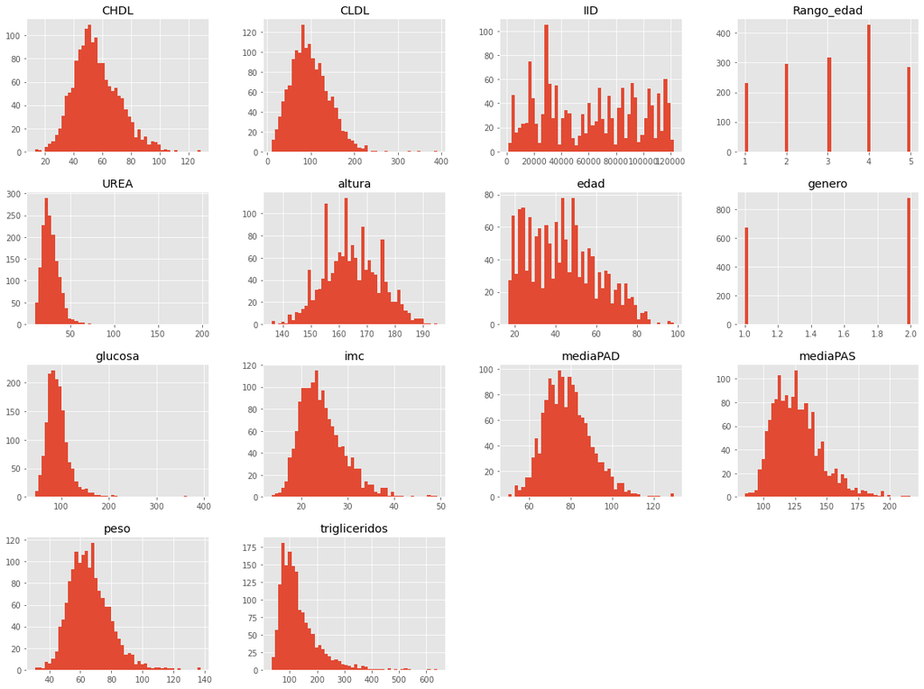

```python
import matplotlib.pyplot as plt
data.hist(bins=50, figsize=(20,15))
plt.show()
```

Se ve que muchas variables presentan comportamientos cercanos a la normalidad como la altura, el imc, el peso, la presión diastólica y sistólica, glucosa. Sin embargo, algunas de esas variables presentan altos valores atipicos. A continuación se presenta la amtriz de correlación de los datos.

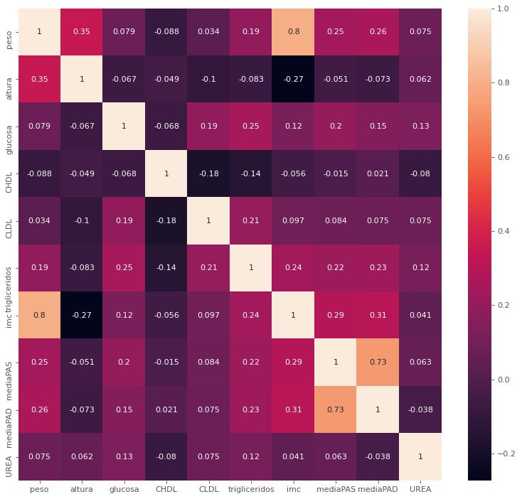

```python
import seaborn as sns

fig = plt.figure(figsize=(12, 11), dpi=80)
# taking all rows but only 6 columns
cdf = data.iloc[:,4:]

correlation_mat = cdf.corr()

sns.heatmap(correlation_mat, annot = True)
plt.show()
```